## R markdown vs R markdown notebooks

The first thing I did was to change the output type from `html_document`, to `html_notebook: default`

*The benefit of this is that the notebook keeps a saved version of the document and incorporates additions, rather than having to re-render the entire document each time

*uses preview, rather than knit

In general, Rmarkdown separates sections via three ```.

- these sections are known as ‘code chunks’
  - they organise your document for easier reading
    - you can quickly insert chunks by pressing **ctrl + alt + I**
    - alternatively, you can add chunks with the add chunk button (green c with a plus)

For annotations that explain code, leave them out of code chunks.

## Formatting

There are many formatting options available in markdown including

- *italics*
- **bold**
- `code`
- you may also want to produce a<sub>subscript</sub> or a<sup>superscript</sup>

In addition, you can make heading levels by adding # at the front of the line, these headings can also have in-line formatting;

# Header 1

## Header 2

### Header 3

To produce the file you have been working on in Rmarkdown either click the knit button, or use **ctrl + shift + k**

For a detailed list of formatting please see this [link](https://pandoc.org/MANUAL.html#pandocs-markdown)

The guide I used to create this can be found at: https://www.dataquest.io/blog/r-markdown-guide-cheatsheet/

# Bullet points and numbered lists

- List element 1
- List element 2
  - List item 1
1. item 1
   - item 1a
2. item 2
3. item 3
   - item 3a _______________________________________________________________

Rmarkdown provides an excellent method to integrate text into writing scripts, from simply annotating code for easier reading, up to producing documents and powerpoint presentations.

Images and figures are integrated straight into the document, and code can be run directly in the script to display the output while you work.

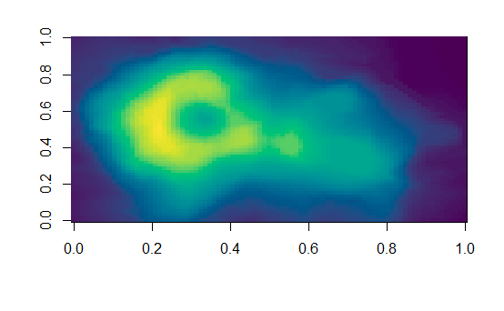

You can create, and alter dataframes much the same as you would in Rstudio

|  | rand_numb1 | speed |
| --- | --- | --- |
| 1 | 1 | 10 |
| 2 | 3 | 20 |
| 3 | 7 | 30 |
| 4 | 5 | 40 |
| 5 | 4 | 50 |
| 6 | 7 | 60 |

```
   rand_numb1        speed
 Min.   :1.000   Min.   :10
 1st Qu.:3.000   1st Qu.:30
 Median :5.000   Median :50
 Mean   :4.889   Mean   :50
 3rd Qu.:7.000   3rd Qu.:70
 Max.   :8.000   Max.   :90
```

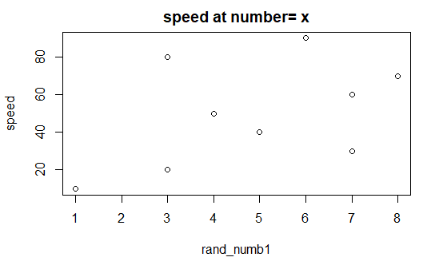

# **Alternate code languages**

The knitr function also has functionaility in a variety of other porgramming languages, including;

- Python
- SQL
- Bash
- Rcpp
- Stan
- JavaScript
- CSS

All that is necessary is to change the **r** preface at the start of a code chunk

etc.

The advantage of this is that it allows integration of the script across a multitude of different coding langauges. This can be useful, for example if you have specific processes that requires programs not available in R

- For example, in my case I used many program suites not available in R for data preparation and filtration.
  - At the time I had to maintain multiple different scripts across the programs to handle this, but had I used Rmarkdown it would have allowed me to contain it all within the single script.